# Lesson 5: Plotting

One of the most useful things in R is the myriad of ways it can visualize data in an appealing way. Let’s dive in. The `plot(x,y)` function will produce a scatterplot,

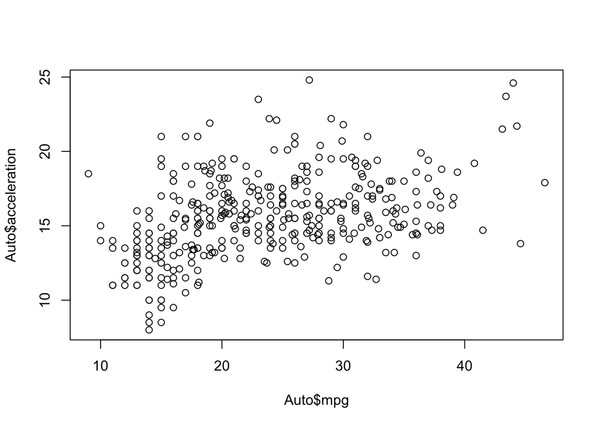

```r
#plot(x,y)
plot(Auto$mpg, Auto$acceleration)
```

Okay, maybe I didn’t start out on the best foot. That’s not the prettiest thing in the world. Let’s try again.

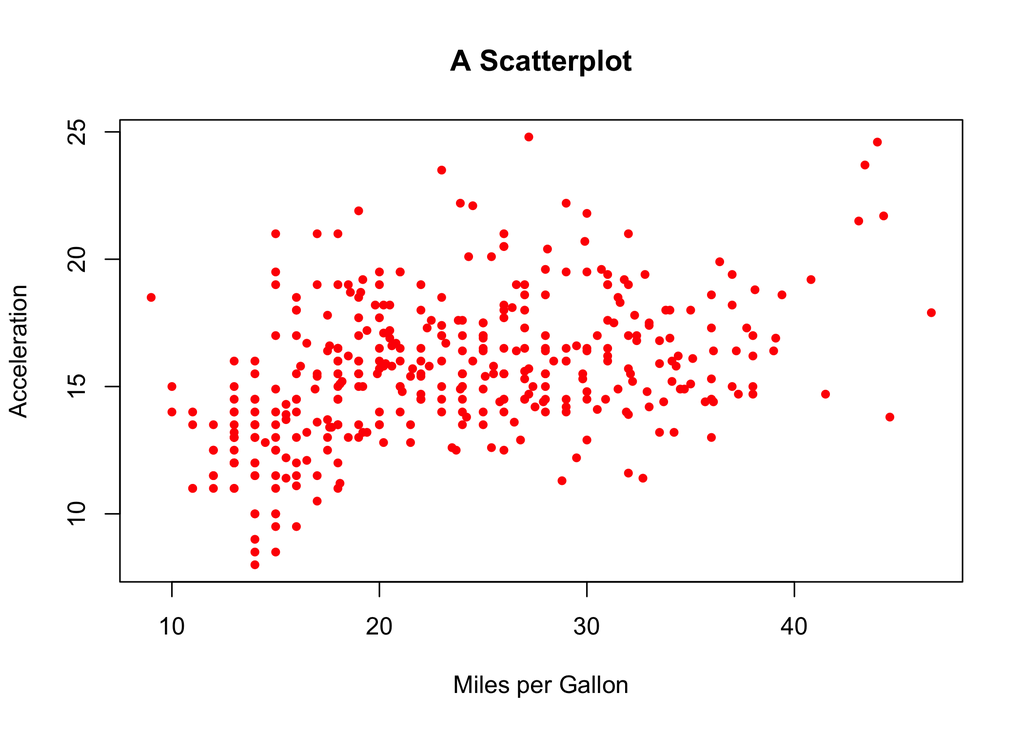

```r
#First lets figure out what acceleration is: we can look at datasets if they have documentation
?Auto
#Now lets make our graph look a bit better
#Col will set a color, xlab will label the x-axis, ylab will label the y-axis, and pch is how plot changes dot shapes.
plot(Auto$mpg, Auto$acceleration, xlab="Miles per Gallon",
     ylab= "Acceleration", main="A Scatterplot",col="red",
     pch=20 )
```

We can also plot a histogram

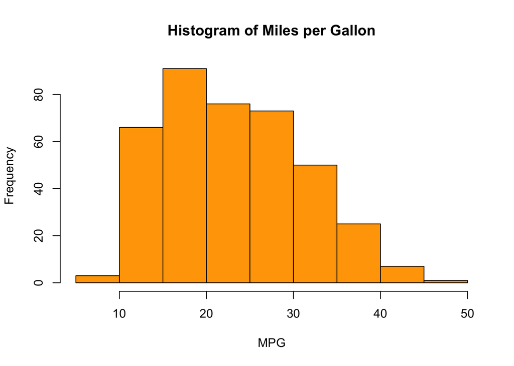

```r
hist(Auto$mpg,main= "Histogram of Miles per Gallon", xlab= "MPG", ylab="Frequency", col = "orange")
```

# Lesson 6: Regression

What you guys came here for! Lots of regression. Regression is fairly straightforward if you are familiar with Stata.

We have a new function, `lm()`, and a new object type, called a `formula`. If we want to run a regression: $Y = \beta*X + \varepsilon$ we have to pass the lm function something it can use to know what to do. We do this with the `y ~ x1 + x2...` format.

```r
#create an object w regression. lm for "linear model"
new_reg = lm(mpg ~ weight, data = Auto)
#and we can use the summary object to get a view very similar to Stata's
summary(new_reg)
```

```
##
## Call:
## lm(formula = mpg ~ weight, data = Auto)
##
## Residuals:
##      Min       1Q   Median       3Q      Max
## -11.9736  -2.7556  -0.3358   2.1379  16.5194
##
## Coefficients:
##              Estimate Std. Error t value Pr(>|t|)
## (Intercept) 46.216524   0.798673   57.87   <2e-16 ***
## weight      -0.007647   0.000258  -29.64   <2e-16 ***
## ---
## Signif. codes:  0 '***' 0.001 '**' 0.01 '*' 0.05 '.' 0.1 ' ' 1
##
## Residual standard error: 4.333 on 390 degrees of freedom
## Multiple R-squared:  0.6926, Adjusted R-squared:  0.6918
## F-statistic: 878.8 on 1 and 390 DF,  p-value: < 2.2e-16
```

Also, we can run regressions without defining a dataset.

```r
#We don't NEED to pass a dataset, but we need to tell lm where to find the information. We can do that this way as well.
summary(lm(Auto$mpg ~ Auto$weight))
```

```
##
## Call:
## lm(formula = Auto$mpg ~ Auto$weight)
##
## Residuals:
##      Min       1Q   Median       3Q      Max
## -11.9736  -2.7556  -0.3358   2.1379  16.5194
##
## Coefficients:
##              Estimate Std. Error t value Pr(>|t|)
## (Intercept) 46.216524   0.798673   57.87   <2e-16 ***
## Auto$weight -0.007647   0.000258  -29.64   <2e-16 ***
## ---
## Signif. codes:  0 '***' 0.001 '**' 0.01 '*' 0.05 '.' 0.1 ' ' 1
##
## Residual standard error: 4.333 on 390 degrees of freedom
## Multiple R-squared:  0.6926, Adjusted R-squared:  0.6918
## F-statistic: 878.8 on 1 and 390 DF,  p-value: < 2.2e-16
```

On your own, interpret these coefficients? What do these mean?

```r
#Let's do another regression. This time, looking at the effect of origin on miles per gallon.
origin_reg <- lm(mpg ~ origin, data = Auto)
summary(origin_reg)
```

```
##
## Call:
## lm(formula = mpg ~ origin, data = Auto)
##
## Residuals:
##      Min       1Q   Median       3Q      Max
## -13.2416  -5.2533  -0.7651   3.8967  18.7115
##
## Coefficients:
##             Estimate Std. Error t value Pr(>|t|)
## (Intercept)  14.8120     0.7164   20.68   <2e-16 ***
## origin        5.4765     0.4048   13.53   <2e-16 ***
## ---
## Signif. codes:  0 '***' 0.001 '**' 0.01 '*' 0.05 '.' 0.1 ' ' 1
##
## Residual standard error: 6.447 on 390 degrees of freedom
## Multiple R-squared:  0.3195, Adjusted R-squared:  0.3177
## F-statistic: 183.1 on 1 and 390 DF,  p-value: < 2.2e-16
```

Notice that `origin` variable is coded as numeric, but it really is a categorical varialbe (1 = American, 2 = European, 3 = Japanese). R doesn’t know this, so it’s treating it as if ‘3’ is 3 times as origin-y as ‘1’. We don’t want that.

```r
#R is treating origin as a...
(class(Auto$origin))
```

```
## [1] "numeric"
```

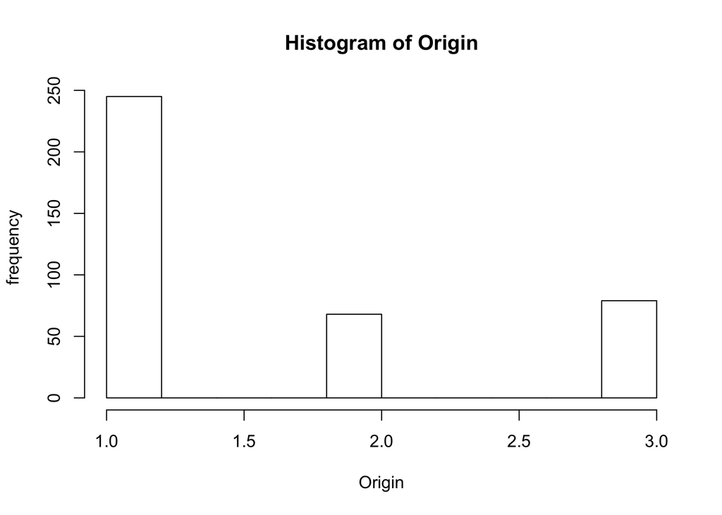

```r
#To visualize...
hist(Auto$origin,main= "Histogram of Origin", xlab= "Origin", ylab="frequency")
```

There’s a way to fix this, by redefining `Auto$origin` using the `as.character()` function.

```r
origin_reg <- lm(mpg ~ as.character(origin), data = Auto)
summary(origin_reg)
```

```
##
## Call:
## lm(formula = mpg ~ as.character(origin), data = Auto)
##
## Residuals:
##     Min      1Q  Median      3Q     Max
## -12.451  -5.034  -1.034   3.649  18.966
##
## Coefficients:
##                       Estimate Std. Error t value Pr(>|t|)
## (Intercept)            20.0335     0.4086  49.025   <2e-16 ***
## as.character(origin)2   7.5695     0.8767   8.634   <2e-16 ***
## as.character(origin)3  10.4172     0.8276  12.588   <2e-16 ***
## ---
## Signif. codes:  0 '***' 0.001 '**' 0.01 '*' 0.05 '.' 0.1 ' ' 1
##
## Residual standard error: 6.396 on 389 degrees of freedom
## Multiple R-squared:  0.3318, Adjusted R-squared:  0.3284
## F-statistic:  96.6 on 2 and 389 DF,  p-value: < 2.2e-16
```

When `lm()` sees a character value, it will automatically treat that variable as a dummy variable. Now, origin is equal to “1” rather than 1.

As an aside, and to test your memory: what is the interpretation of the intercept here?

If we wanted, we could also remove the intercept. This might give you a hint to the question above:

```r
#remove the intercept: we can do this by adding a '-1' into our formula.
origin_reg_no_int <- lm(mpg ~ as.character(origin)-1, data = Auto)
summary(origin_reg_no_int)
```

```
##
## Call:
## lm(formula = mpg ~ as.character(origin) - 1, data = Auto)
##
## Residuals:
##     Min      1Q  Median      3Q     Max
## -12.451  -5.034  -1.034   3.649  18.966
##
## Coefficients:
##                       Estimate Std. Error t value Pr(>|t|)
## as.character(origin)1  20.0335     0.4086   49.02   <2e-16 ***
## as.character(origin)2  27.6029     0.7757   35.59   <2e-16 ***
## as.character(origin)3  30.4506     0.7196   42.31   <2e-16 ***
## ---
## Signif. codes:  0 '***' 0.001 '**' 0.01 '*' 0.05 '.' 0.1 ' ' 1
##
## Residual standard error: 6.396 on 389 degrees of freedom
## Multiple R-squared:  0.9335, Adjusted R-squared:  0.933
## F-statistic:  1820 on 3 and 389 DF,  p-value: < 2.2e-16
```

And that’s it! Welcome to R. Please feel free to play around with the datasets and get comfortable slicing dataframes, since you will likely be doing that often.

As practice, play around running regressions in the `ISLR` ‘College’ dataset. Run a regression on your own, and try to look at entire rows or entire columns to familiarize yourself with R.

Good luck, and I’ll see you next week.